# CONS7008 Assignment

Scientific webpage to inform National Park management

# Introduction

Chytridiomycosis is a worldwide infectious disease that affects amphibians, and it is caused by the chytrid fungus known as Batrachochytrium dendrobatidis. This fungus has the potential to cause occasional deaths in specific amphibian populations, sometimes leading to total mortality. An experiment conducted by Berger et al. (1998) revealed that the fungus infiltrated the surface layers of the frog’s skin, causing harm to the outer keratin layer and resulting in a 100% mortality rate within three weeks. Additionally, in 1997, scientists also observed rainforest frogs succumbing to chytridiomycosis during an outbreak in Panama, confirming that this disease was responsible for widespread declines of some amphibian population globally (Berger et al. (1998)). Chytridiomycosis has established itself as an endemic presence in many regions, typically with a prevalence exceeding 5%, and it is prone to seasonal disease outbreaks (Berger et al. (2016)). In Australia, this fungus has been directly linked to the extinction of a minimum of four species and the significant reduction in population for at least 10 others, including the waterfall frog (Litoria nannotis), common mistfrog (Litoria rheocola), spotted tree frog (Litoria spenceri), and lace-eyed tree frog (Nycitmystes dayi).

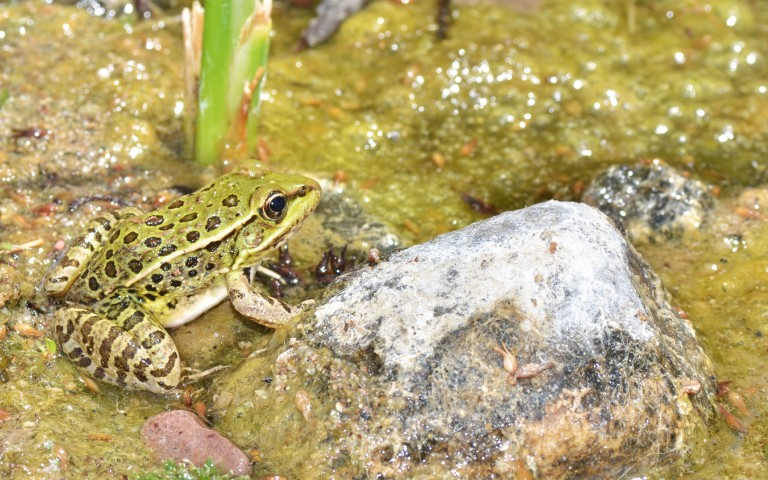

Figure. The lowland leopard frog, found in river drainages in Arizona, is ingected by Batrachochytrium dendrobatidis chytrid fungus

In this report, we will provide a statistical model and analysis results associated with Chytrid fungus in three species of amphibian across 15 National Parks in QLD’s Wet Tropics Bioregion. We then propose some recommendations aimed at mitigating the risks to native amphibian species in their National Park estate.

# Materials

Table 1. National Park Data

| Variables | Description | Type |
| --- | --- | --- |
| NP | Code for each of the 15 National Parks (NPs) sampled | Nominal |
| VPD | Mean annual Vapour Pressure Deficit (VPD; how dry the atmosphere is; higher is drier) for each NP | Numeric |
| NP_area_1000_ha | The area of the NP (in thousands of hectares) | Numeric |
| visit_rate_1000_per_yr | Average number of visitors per year in thousands | Numeric |
| frog_spp_richness | Number of amphibian species recorded in each NP during surveys conducted between 2010 and 2020 | Numeric |
| plant_spp_richness | Number of plant species recorded in each NP during suverys conducted between 2010 and 2020 | Numeric |

Table 2. Chytrid Amphibian Data

| Variables | Description | Type |
| --- | --- | --- |
| NP | Code for each of the 15 National Parks (NPs) sampled | Nominal |
| creek_id | The ID number for each creek sampled for frogs and toads in each NP | Nominal |
| track_density | The density of walking tracks within a 500m radius of each creek sampling site | Numeric |
| pop_density | The estimated density of the frog/toad population in each sampled creek | Numeric |
| species | The species of frog or toad. These are Taudactylus acutirostris, Rhinella marina and Taudactylus rheophilus | Nominal |
| n_frogs_sampled | The number of frogs of each species sampled in each creek | Numeric |
| n_infected | The number of sampled frogs/toads that had visible signs of Chytrid infection | Numeric |

# Data analysis

## Exploratory data analysis

Summarize data

- National Park Data

```r
NatParkData$NP<-factor(NatParkData$NP)
summary(NatParkData)
```

```
##        NP         VPD         NP_area_1000_ha  visit_rate_1000_per_yr
##  NP_A   :1   Min.   :0.7424   Min.   :0.4717   Min.   : 0.577
##  NP_B   :1   1st Qu.:1.0862   1st Qu.:4.4606   1st Qu.: 2.447
##  NP_C   :1   Median :1.4804   Median :5.8607   Median : 8.274
##  NP_D   :1   Mean   :1.5691   Mean   :6.4285   Mean   : 6.712
##  NP_E   :1   3rd Qu.:2.0242   3rd Qu.:9.2296   3rd Qu.: 8.488
##  NP_F   :1   Max.   :2.6089   Max.   :9.7384   Max.   :14.887
##  (Other):9
##  frog_spp_richness plant_spp_richness
##  Min.   : 5.00     Min.   : 81.0
##  1st Qu.: 8.50     1st Qu.:160.0
##  Median :15.00     Median :172.0
##  Mean   :14.47     Mean   :197.0
##  3rd Qu.:19.00     3rd Qu.:253.5
##  Max.   :25.00     Max.   :309.0
##
```

- Chytrid Chytrid Amphibian Data

```r
ChytridAmpData$NP<-factor(ChytridAmpData$NP)
ChytridAmpData$creek_id<-factor(ChytridAmpData$creek_id)
ChytridAmpData$species<-factor(ChytridAmpData$species, levels=c("Taudactylus acutirostris","Taudactylus rheophilus","Rhinella marina"))
summary(ChytridAmpData)
```

```
##        NP         creek_id   track_density     pop_density
##  NP_A   : 15   NP_A_1 :  3   Min.   : 1.645   Min.   :0.1000
##  NP_B   : 15   NP_A_2 :  3   1st Qu.: 4.562   1st Qu.:0.3846
##  NP_C   : 15   NP_A_3 :  3   Median : 6.966   Median :0.6055
##  NP_D   : 15   NP_A_4 :  3   Mean   : 6.957   Mean   :0.5954
##  NP_E   : 15   NP_A_5 :  3   3rd Qu.: 9.038   3rd Qu.:0.8104
##  NP_F   : 15   NP_B_1 :  3   Max.   :13.060   Max.   :1.0590
##  (Other):135   (Other):207
##                      species   n_frogs_sampled   n_infected
##  Taudactylus acutirostris:75   Min.   : 5.00   Min.   : 0.000
##  Taudactylus rheophilus  :75   1st Qu.: 9.00   1st Qu.: 0.000
##  Rhinella marina         :75   Median :11.00   Median : 1.000
##                                Mean   :12.22   Mean   : 1.853
##                                3rd Qu.:15.00   3rd Qu.: 2.000
##                                Max.   :25.00   Max.   :15.000
##
```

First, take a look into Chytrid Amphibian Data. We calculate propotion of normal frogs in each creak.

```r
ChytridAmpData$normal_frogs_prop<-(ChytridAmpData$n_frogs_sampled - ChytridAmpData$n_infected)/ChytridAmpData$n_frogs_sampled
```

Let’s draw some histograms.

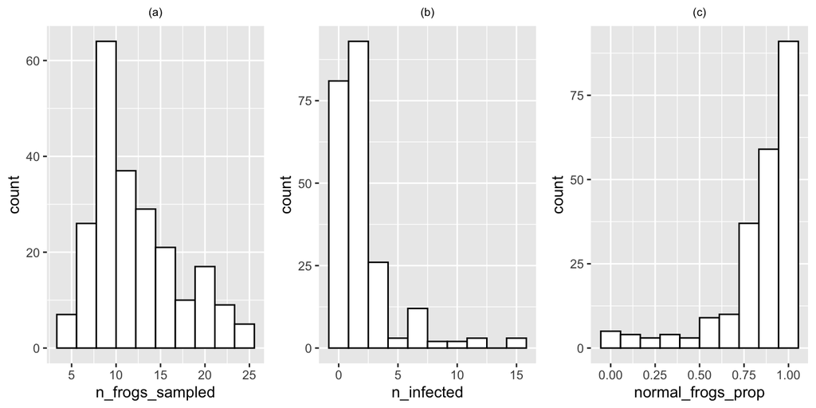

Figure. Histogram of (a) the number of frogs of each species sampled in each creek, (b) the number of sampled frogs/toads that had visible signs of Chytrid infection and (c) the propotion of healthy(normal) sampled frogs/toads

We notice that these distributions are not normal.

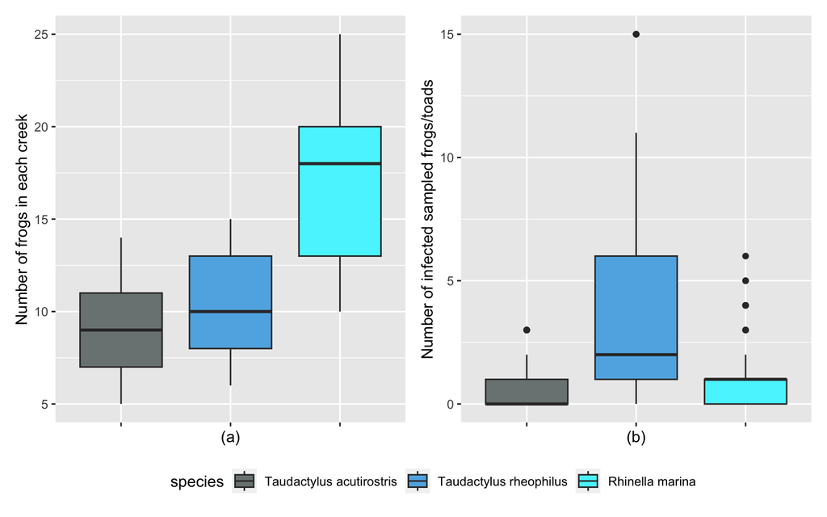

Figure. Boxplot (a) number of frogs sampled in three species and (b) number of sampled frogs/toads that had visible signs of Chytrid infection in three species.

From these plots, it’s evident that *Rhinella marina* has the highest population. In contrast, *Taudactylus acutirostris* has the smallest number of frogs, and interestingly, they also exhibit the lowest number of infected individuals. *Taudactylus rheophilus*, however, has the highest number of infected individuals among the species.

Simultaneously, we aim to examine whether there is any interaction between the estimated density of the frog/toad population and the proportion of healthy frogs within each surveyed creek.

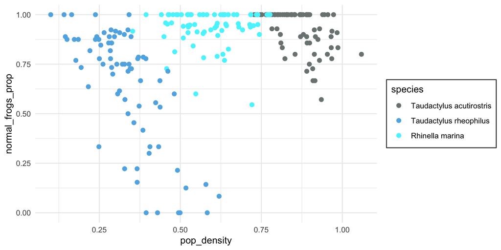

Figure. Scatterplot of healthy(normal) frogs propotion relative to population density among three species.

The figure above shows the effect of the proportion of healthy frogs on population density depends on which species they belong to.

## Models

Rather than utilizing a pre-calculated proportion as the response variable in our analysis, it would be more suitable to create a new response variable. To do this, we will establish a variable that represents the count of healthy frogs.

```r
ChytridAmpData$n_no_infected<-ChytridAmpData$n_frogs_sampled - ChytridAmpData$n_infected
```

In this analysis, our primary interest lies in understanding the number of healthy frogs, but it’s essential to factor in the total number of frogs sampled in each creek as well. Consequently, we will employ a generalized linear model (GLM) for this analysis. The response variable is not a single variable; rather, it comprises a combination of ‘n_infected’ and ‘n_no_infected’ to form a comprehensive response variable.

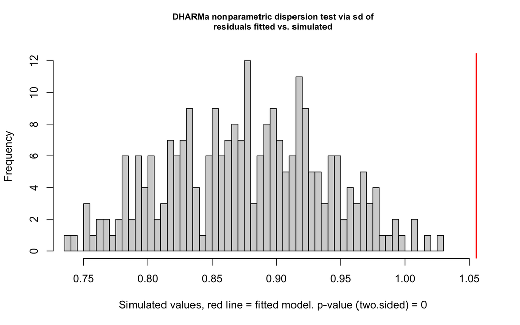

```
##
##  DHARMa nonparametric dispersion test via sd of residuals fitted vs.
##  simulated
##
## data:  simulationOutput
## dispersion = 1.2034, p-value < 2.2e-16
## alternative hypothesis: two.sided
```

```r
ChytridAmp_glm_1 <- glm(cbind(n_infected, n_no_infected) ~ track_density + pop_density + species + NP, family="binomial", data = ChytridAmpData)
testDispersion(simulateResiduals(ChytridAmp_glm_1))
```

In this case, the model is very overdispersed. We “mop up” the overdispersion using a random effect which assumes a normal distribution. To do that, we will create a ID column (a unique number for each row of data).

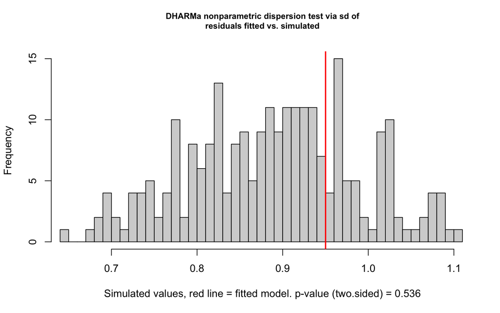

```
##
##  DHARMa nonparametric dispersion test via sd of residuals fitted vs.
##  simulated
##
## data:  simulationOutput
## dispersion = 1.0702, p-value = 0.536
## alternative hypothesis: two.sided
```

```r
ChytridAmpData$ID = c(1:dim(ChytridAmpData)[1])
ChytridAmp_glm_2 <- suppressWarnings(glmer(cbind(n_infected, n_no_infected) ~ track_density + pop_density + species + NP + (1|ID), family="binomial", data = ChytridAmpData))
testDispersion(simulateResiduals(ChytridAmp_glm_2))
```

```r
summary(ChytridAmp_glm_2)
```

```
## Generalized linear mixed model fit by maximum likelihood (Laplace
##   Approximation) [glmerMod]
##  Family: binomial  ( logit )
## Formula: cbind(n_infected, n_no_infected) ~ track_density + pop_density +
##     species + NP + (1 | ID)
##    Data: ChytridAmpData
##
##      AIC      BIC   logLik deviance df.resid
##    642.4    710.8   -301.2    602.4      205
##
## Scaled residuals:
##     Min      1Q  Median      3Q     Max
## -1.3768 -0.5540 -0.2282  0.5295  2.3384
##
## Random effects:
##  Groups Name        Variance Std.Dev.
##  ID     (Intercept) 0.3882   0.6231
## Number of obs: 225, groups:  ID, 225
##
## Fixed effects:
##                               Estimate Std. Error z value Pr(>|z|)
## (Intercept)                   -8.11435    0.97228  -8.346  < 2e-16 ***
## track_density                  0.12704    0.02839   4.476 7.62e-06 ***
## pop_density                    5.80173    0.97656   5.941 2.83e-09 ***
## speciesTaudactylus rheophilus  5.40833    0.58379   9.264  < 2e-16 ***
## speciesRhinella marina         1.48150    0.36141   4.099 4.15e-05 ***
## NPNP_B                        -1.71661    0.49080  -3.498 0.000469 ***
## NPNP_C                        -0.29813    0.40363  -0.739 0.460133
## NPNP_D                        -0.25539    0.39347  -0.649 0.516298
## NPNP_E                        -0.99855    0.42892  -2.328 0.019909 *
## NPNP_F                        -0.47353    0.39648  -1.194 0.232349
## NPNP_G                        -1.43364    0.44734  -3.205 0.001352 **
## NPNP_H                         0.49568    0.39826   1.245 0.213268
## NPNP_I                        -2.13182    0.52187  -4.085 4.41e-05 ***
## NPNP_J                        -0.62723    0.40313  -1.556 0.119738
## NPNP_K                        -0.14345    0.38448  -0.373 0.709067
## NPNP_L                        -1.05100    0.41234  -2.549 0.010807 *
## NPNP_M                        -0.64192    0.41485  -1.547 0.121777
## NPNP_N                        -2.22983    0.53833  -4.142 3.44e-05 ***
## NPNP_O                        -1.34492    0.42771  -3.144 0.001664 **
## ---
## Signif. codes:  0 '***' 0.001 '**' 0.01 '*' 0.05 '.' 0.1 ' ' 1
```

```
##
## Correlation matrix not shown by default, as p = 19 > 12.
## Use print(x, correlation=TRUE)  or
##     vcov(x)        if you need it
```

```
## optimizer (Nelder_Mead) convergence code: 0 (OK)
## Model failed to converge with max|grad| = 0.24288 (tol = 0.002, component 1)
```

Now, let’s delve deeper into the dataset. The data exhibits a specific structure where each National Park (NP) consists of five creeks. Given that creeks in our NPs differ systematically across each NP, but we don’t want to explicitly estimate differences for each NP, we could consider “partially” pooling site observations together in a mixed-effects model.

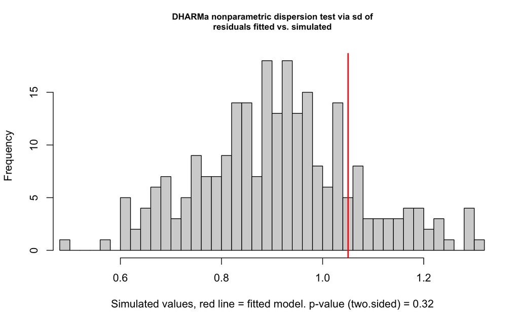

```
##
##  DHARMa nonparametric dispersion test via sd of residuals fitted vs.
##  simulated
##
## data:  simulationOutput
## dispersion = 1.1538, p-value = 0.32
## alternative hypothesis: two.sided
```

```r
ChytridAmp_glm_3 <- glmer(cbind(n_infected, n_no_infected) ~ track_density + pop_density + species + (1|ID) + (1|NP), family="binomial", data = ChytridAmpData)
testDispersion(simulateResiduals(ChytridAmp_glm_3))
```

```r
summary(ChytridAmp_glm_3)
```

```
## Generalized linear mixed model fit by maximum likelihood (Laplace
##   Approximation) [glmerMod]
##  Family: binomial  ( logit )
## Formula: cbind(n_infected, n_no_infected) ~ track_density + pop_density +
##     species + (1 | ID) + (1 | NP)
##    Data: ChytridAmpData
##
##      AIC      BIC   logLik deviance df.resid
##    657.4    681.3   -321.7    643.4      218
##
## Scaled residuals:
##     Min      1Q  Median      3Q     Max
## -1.3321 -0.5728 -0.2975  0.4301  2.1000
##
## Random effects:
##  Groups Name        Variance Std.Dev.
##  ID     (Intercept) 0.4787   0.6919
##  NP     (Intercept) 0.4288   0.6548
## Number of obs: 225, groups:  ID, 225; NP, 15
##
## Fixed effects:
##                               Estimate Std. Error z value Pr(>|z|)
## (Intercept)                   -9.29284    0.95682  -9.712  < 2e-16 ***
## track_density                  0.12740    0.02946   4.325 1.53e-05 ***
## pop_density                    6.17479    1.00977   6.115 9.65e-10 ***
## speciesTaudactylus rheophilus  5.61173    0.60418   9.288  < 2e-16 ***
## speciesRhinella marina         1.59332    0.37291   4.273 1.93e-05 ***
## ---
## Signif. codes:  0 '***' 0.001 '**' 0.01 '*' 0.05 '.' 0.1 ' ' 1
##
## Correlation of Fixed Effects:
##             (Intr) trck_d pp_dns spcsTr
## track_dnsty -0.203
## pop_density -0.931 -0.044
## spcsTdctylr -0.934 -0.009  0.925
## spcsRhnllmr -0.813 -0.006  0.760  0.861
```

Based on the model presented above, it’s evident that there are strong correlations between population density and species (Correlation of Fixed Effects). As a result, we aim to assess the model’s performance when excluding the population density attribute.

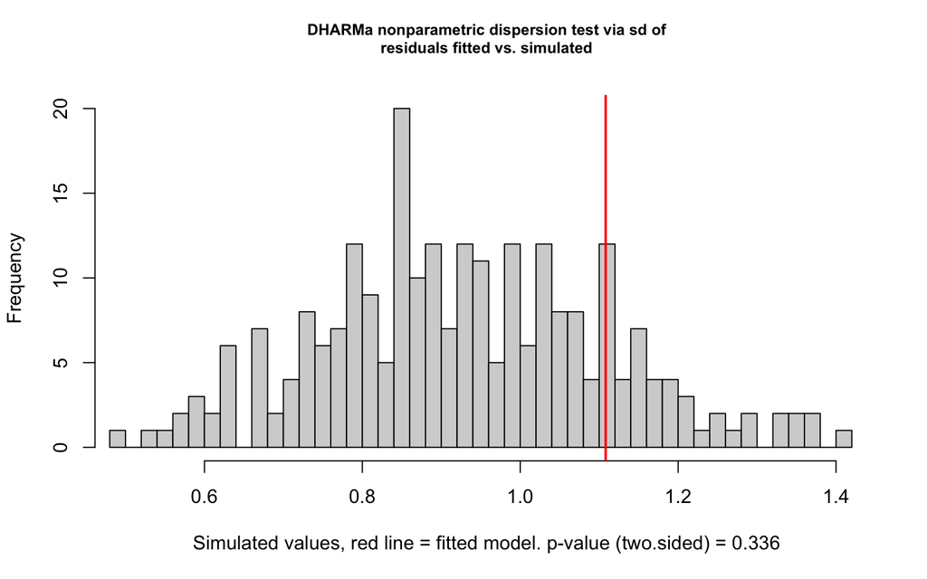

```
##
##  DHARMa nonparametric dispersion test via sd of residuals fitted vs.
##  simulated
##
## data:  simulationOutput
## dispersion = 1.1948, p-value = 0.336
## alternative hypothesis: two.sided
```

```r
ChytridAmp_glm_4 <- glmer(cbind(n_infected, n_no_infected) ~ track_density + species + (1|ID) + (1|NP), family="binomial", data = ChytridAmpData)
testDispersion(simulateResiduals(ChytridAmp_glm_4))
```

```r
summary(ChytridAmp_glm_4)
```

```
## Generalized linear mixed model fit by maximum likelihood (Laplace
##   Approximation) [glmerMod]
##  Family: binomial  ( logit )
## Formula: cbind(n_infected, n_no_infected) ~ track_density + species +
##     (1 | ID) + (1 | NP)
##    Data: ChytridAmpData
##
##      AIC      BIC   logLik deviance df.resid
##    693.1    713.6   -340.6    681.1      219
##
## Scaled residuals:
##     Min      1Q  Median      3Q     Max
## -1.1241 -0.5630 -0.2710  0.4906  2.0622
##
## Random effects:
##  Groups Name        Variance Std.Dev.
##  ID     (Intercept) 0.7082   0.8415
##  NP     (Intercept) 0.6106   0.7814
## Number of obs: 225, groups:  ID, 225; NP, 15
##
## Fixed effects:
##                               Estimate Std. Error z value Pr(>|z|)
## (Intercept)                   -4.13793    0.38501 -10.748  < 2e-16 ***
## track_density                  0.14995    0.03222   4.654 3.26e-06 ***
## speciesTaudactylus rheophilus  2.34577    0.24577   9.545  < 2e-16 ***
## speciesRhinella marina        -0.14187    0.26011  -0.545    0.585
## ---
## Signif. codes:  0 '***' 0.001 '**' 0.01 '*' 0.05 '.' 0.1 ' ' 1
##
## Correlation of Fixed Effects:
##             (Intr) trck_d spcsTr
## track_dnsty -0.656
## spcsTdctylr -0.502  0.076
## spcsRhnllmr -0.411  0.023  0.622
```

```r
emmeans(object = ChytridAmp_glm_4, specs = pairwise~species)
```

```
## $emmeans
##  species                  emmean    SE  df asymp.LCL asymp.UCL
##  Taudactylus acutirostris -3.095 0.292 Inf     -3.67    -2.522
##  Taudactylus rheophilus   -0.749 0.243 Inf     -1.22    -0.273
##  Rhinella marina          -3.237 0.271 Inf     -3.77    -2.706
##
## Results are given on the logit (not the response) scale.
## Confidence level used: 0.95
##
## $contrasts
##  contrast                                          estimate    SE  df z.ratio
##  Taudactylus acutirostris - Taudactylus rheophilus   -2.346 0.246 Inf  -9.545
##  Taudactylus acutirostris - Rhinella marina           0.142 0.260 Inf   0.545
##  Taudactylus rheophilus - Rhinella marina             2.488 0.220 Inf  11.286
##  p.value
##   <.0001
##   0.8488
##   <.0001
##
## Results are given on the log odds ratio (not the response) scale.
## P value adjustment: tukey method for comparing a family of 3 estimates
```

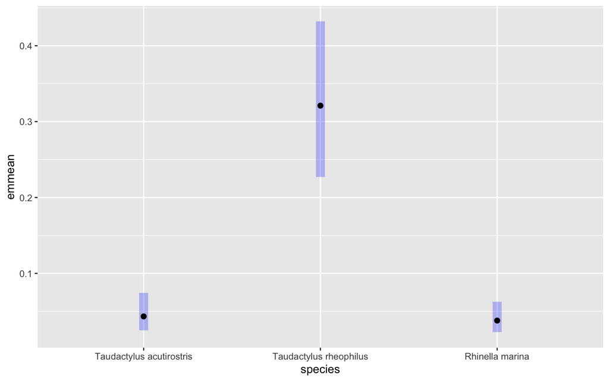

```r
plot(emmeans(ChytridAmp_glm_4, ~species, type = "response"), horizontal=F)
```

When examining random effects, we can compute the proportion of variance explained, which helps us determine the significance of this effect.

```r
0.6106/(0.6106 + 0.7082)
```

```
## [1] 0.4629967
```

So, we can see that 46% of the total variance of random effects is attributed to the NPs.

Let’s look at the National Park Data.

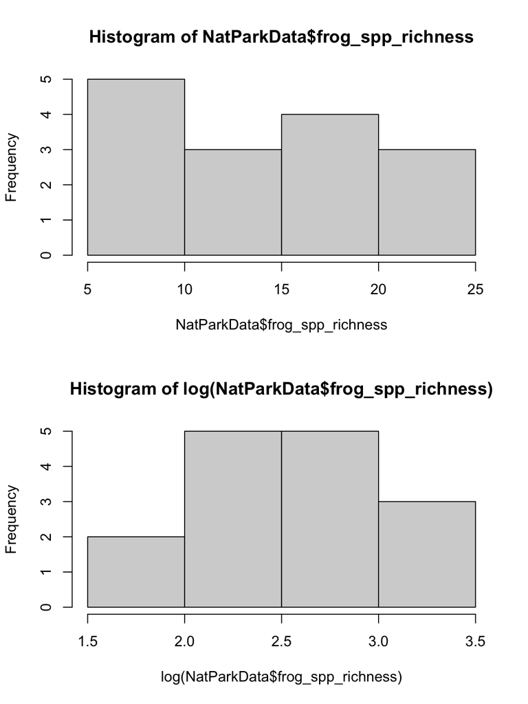

We use log(frog_spp_richness) as response variable in this model.

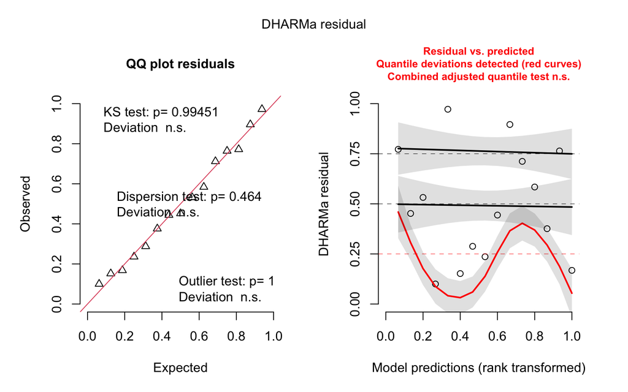

```r
NatParkData_lm<-lm(log(frog_spp_richness) ~ VPD + NP_area_1000_ha + visit_rate_1000_per_yr + plant_spp_richness, data = NatParkData)
plot(simulateResiduals(NatParkData_lm))
```

```r
summary(NatParkData_lm)
```

```
##
## Call:
## lm(formula = log(frog_spp_richness) ~ VPD + NP_area_1000_ha +
##     visit_rate_1000_per_yr + plant_spp_richness, data = NatParkData)
##
## Residuals:
##      Min       1Q   Median       3Q      Max
## -0.44897 -0.20915  0.00218  0.16585  0.57205
##
## Coefficients:
##                          Estimate Std. Error t value Pr(>|t|)
## (Intercept)             2.5864679  0.6360691   4.066  0.00226 **
## VPD                    -0.1132923  0.1974309  -0.574  0.57876
## NP_area_1000_ha         0.1026037  0.0479339   2.141  0.05798 .
## visit_rate_1000_per_yr -0.0486994  0.0255714  -1.904  0.08599 .
## plant_spp_richness     -0.0008734  0.0022902  -0.381  0.71090
## ---
## Signif. codes:  0 '***' 0.001 '**' 0.01 '*' 0.05 '.' 0.1 ' ' 1
##
## Residual standard error: 0.3303 on 10 degrees of freedom
## Multiple R-squared:  0.6749, Adjusted R-squared:  0.5449
## F-statistic:  5.19 on 4 and 10 DF,  p-value: 0.01588
```

We can see from the figure above that most of variables are not significant, only NP_area_1000_ha and visit_rate_1000_per_yr are slightly significant(<0.1). Beside that we also want to examine whether any correlation between these variables and richness of frogs.

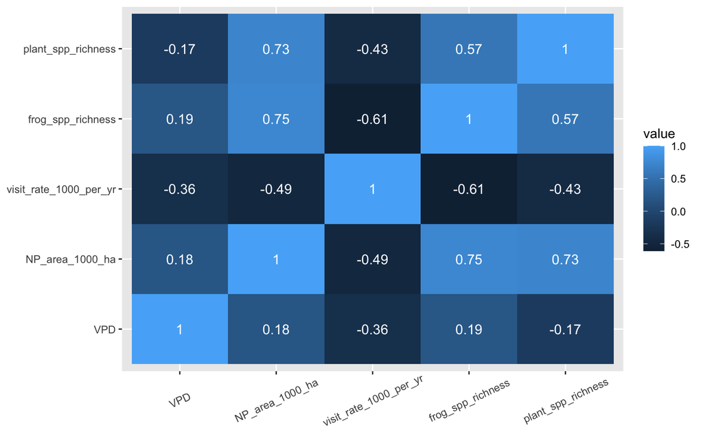

Figure. Heatmap of National Park data variables

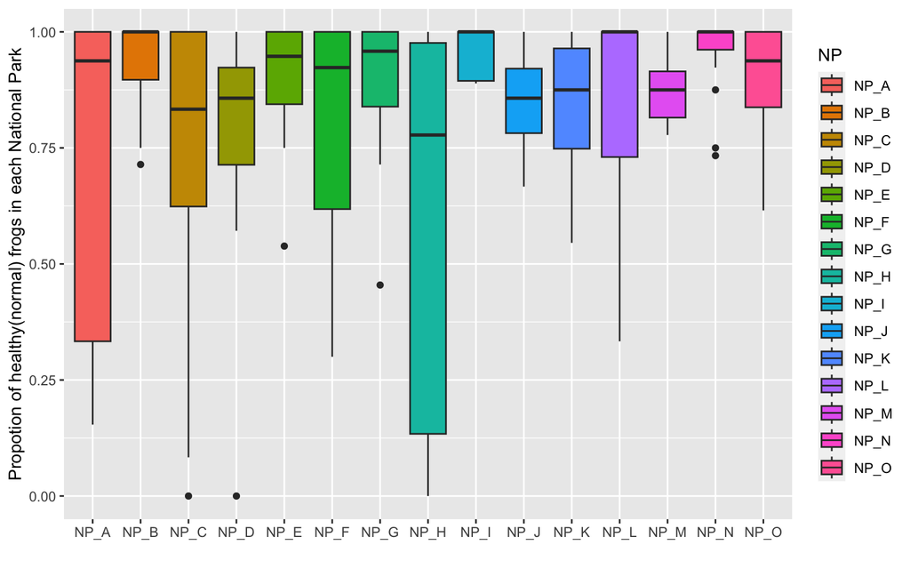

Figure. Propotion of healthy(normal) frogs in 15 National Parks

# Discussion and Recommendations

Based on our comprehensive analysis, it is evident that distinct strategies should be tailored for different species. Notably, Taudactylus rheophilus stands out as the species at the highest risk. For this species, we recommend a combination of short-term and long-term measures. In the short term, swift action is essential. Implementing quarantine protocols at park entrances to prevent potential carriers of the fungus from entering the park, such as contaminated equipment or clothing, can be enacted quickly, resulting in immediate impact. Simultaneously, for long-term disease management, we should consider measures such as translocation and reintroduction, which are common strategies for preserving this species. Within the broader category of “conservation translocations”, Scheele et al. (2021) encompass the following actions: (a) reintroduction, which involves releasing animals into regions from which they have disappeared, with the aim of establishing a population, (b) population augmentation, where animals are introduced into areas where similar species already exist, in order to bolster the overall population’s viability, (c) assisted colonization, a strategy in which animals are introduced beyond their native range to establish a new population and (d) mitigation translocation, a practice in which animals are relocated from habitat that is scheduled for destruction and released into an alternative location. Additionally, in the case of translocations involving amphibians threatened by Batrachochytrium dendrobatidis (Bd), there is frequently a requirement for concurrent monitoring of Bd dynamics. Gathering data on Bd dynamics can aid in distinguishing mortality attributed to Bd from other sources of mortality.

Regarding the National Park data, it’s worth noting that the dataset comprises a limited sample size with only 15 subjects. Drawing definitive conclusions from such a small dataset can be challenging.

# References

Berger, Lee, Alexandra Roberts, Jamie Voyles, Joyce Longcore, Kris Murray, and Lee Skerratt. 2016. “History and Recent Progress on Chytridiomycosis in Amphibians.” *Fungal Ecology* 19 (February): 89–99. https://doi.org/10.1016/j.funeco.2015.09.007.

Berger, Lee, Rick Speare, Peter Daszak, D Earl Green, Andrew A Cunningham, C Louise Goggin, Ron Slocombe, et al. 1998. “Chytridiomycosis Causes Amphibian Mortality Associated with Population Declines in the Rain Forests of Australia and Central America.” *Proceedings of the National Academy of Sciences* 95 (15): 9031–36.

Bosch, Jaime, Eva Sanchez-Tomé, Andrés Fernández-Loras, Joan A Oliver, Matthew C Fisher, and Trenton WJ Garner. 2015. “Successful Elimination of a Lethal Wildlife Infectious Disease in Nature.” *Biology Letters* 11 (11): 20150874.

Scheele, Ben C, Matthijs Hollanders, Emily P Hoffmann, David A Newell, David B Lindenmayer, Michael McFadden, Deon J Gilbert, and Laura F Grogan. 2021. “Conservation Translocations for Amphibian Species Threatened by Chytrid Fungus: A Review, Conceptual Framework, and Recommendations.” *Conservation Science and Practice* 3 (11): e524.